# PG2-Informe

## **III. ANÁLISIS PROBABILÍSTICO**

### **Probabilidad Empírica**

**Datos importantes**

```r
N_total <- nrow(datos_filtrados1)

N_total
```

```
## [1] 163
```

```r
fr1 <- table(datos_filtrados1$Nivel_confianza)
fr1
```

```
##
## Poco confiable        Neutral      Confiable  Muy confiable
##             11             77             66              9
```

```r
fr1_A1 <- fr1["Poco confiable"]
fr1_A1
```

```
## Poco confiable
##             11
```

```r
fr1_A2 <- fr1["Neutral"]
fr1_A2
```

```
## Neutral
##      77
```

```r
fr1_A3 <- fr1["Confiable"]
fr1_A3
```

```
## Confiable
##        66
```

```r
fr1_A4 <- fr1["Muy confiable"]
fr1_A4
```

```
## Muy confiable
##             9
```

```r
fr2 <- table(datos_filtrados1$Percepcion_efectividad)
fr2
```

```
##
## Negativa  Neutral Positiva
##        5       74       84
```

```r
fr2_A1 <- fr2["Negativa"]
fr2_A1
```

```
## Negativa
##        5
```

```r
fr2_A2 <- fr2["Neutral"]
fr2_A2
```

```
## Neutral
##      74
```

```r
fr2_A3 <- fr2["Positiva"]
fr2_A3
```

```
## Positiva
##       84
```

#### **NIVEL DE CONFIANZA**

Experimento : Seleccionar encuestados de los estudiantes de UTEC matriculados en el ciclo 2023 - 1 y observar su percepción de confianza respecto a la veracidad de información que encuentra en línea

**- Espacio de resultados**

Ω = { Poco confiable,Neutral,Confiable,Muy confiable} ->
$$n(Ω) = 4$$

**- Eventos atómicos:**

- A1 = Seleccionar a un estudiante que tenga una percepción de poca confiabilidad respecto a la veracidad de la información que encuentra en línea
- A2 = Seleccionar a un estudiante que tenga una percepción neutral respecto a la veracidad de la información que encuentra en línea
- A3 = Seleccionar a un estudiante que tenga una percepción de confiabilidad respecto a la veracidad de la información que encuentra en línea
- A4 = Seleccionar a un estudiante que tenga una percepción de mucha confiabilidad respecto a la veracidad de la información que encuentra en línea

**- Función probabilidad (Empírica)**

P(A1) = 0.07 = 7 %

P(A3) = 0.4 = 40 %

**- Conclusión:**

Se demostró por parte de los estudiantes una percepción positiva respecto a la veracidad de información encontrada en línea, sin embargo hay muy pocas personas que se encuentran en los extremos de una percepción poco confiable y muy confiable, los estudiantes prefieren mantenerse al margen y muestran una amplia acogida a la veracidad de la información en línea.

```r
PA1 = round(fr1_A1/N_total, 2)

PA1
```

```
## Poco confiable
##           0.07
```

```r
PA2 = round(fr1_A2/N_total, 2)

PA2
```

```
## Neutral
##    0.47
```

```r
PA3 = round(fr1_A3/N_total, 2)

PA3
```

```
## Confiable
##       0.4
```

```r
PA4 = round(fr1_A4/N_total, 2)

PA4
```

```
## Muy confiable
##          0.06
```

#### **PERCEPCIÓN DE EFECTIVIDAD**

Experimento: Seleccionar encuestados de los estudiantes de UTEC matriculados en el ciclo 2023 - 1 y observar su percepción de efectividad de la toma de apuntes digitales respecto a la toma de apuntes tradicionales

**- Espacio de resultados**

Ω = { Negativa,Neutral,Positiva} ->
$$n(Ω) = 3$$

**- Eventos atómicos:**

- A1 = Seleccionar un estudiante que presenta una percepción negativa de la toma de apuntes digitales
- A2 = Seleccionar un estudiante que presenta una percepción neutral de la toma de apuntes digitales
- A3 = Seleccionar un estudiante que presenta una percepción positiva de la toma de apuntes digitales

**- Función probabilidad (Empírica)**

P(A1) = 0.03 = 3 %

**- Conclusión:**

Se demostró una percepción positiva respecto a la toma de apuntes digitales vs la toma de apuntes tradicional, sin embargo no demuestra si es superior a la toma de apuntes tradicionales,pero si muestra gran acogida por casi la mitad de estudiantes que le dieron un visto positivo.

```r
PB1 = round(fr2_A1/N_total, 2)

PB1
```

```
## Negativa
##     0.03
```

```r
PB2 = round(fr2_A2/N_total, 2)

PB2
```

```
## Neutral
##    0.45
```

```r
PB3 = round(fr2_A3/N_total, 2)

PB3
```

```
## Positiva
##     0.52
```

### **Probabilidad Condicional**

#### **EVENTOS INDEPENDIENTES**

**- Utilizaremos las siguientes variables para crear eventos de interés**

- Variable 1 = Medida_responsabilidad
- Variable 2 = Sexo

**- Experimento**

Si seleccionamos al azar de esta población y se encuentra que es hombre. ¿CUÁL ES LA PROBABILIDAD DE QUE SEA MUY RESPONSABLE AL MOMENTO DE MITIGAR INFORMACIÓN NO CONFIABLE?

#### **- Primer paso: Identificar los eventos de cada variable**

- A: Seleccionar a un estudiante de que se perciba como alguien muy responsable para mitigar información no confiable
- B: Seleccionar a un estudiante que sea de sexo masculino

#### **- Segundo paso: Identificar si los eventos son independientes**

Para ello creamos nuestra tabla de contingencia. **- Creamos nuestra tabla de contingencia de EVENTOS**

```
## [1] 163
```

```
##                 Femenino Masculino   Suma
## Muy responsable   0.0552    0.0675 0.1227
## Complemento       0.3988    0.4785 0.8773
## Suma              0.4540    0.5460 1.0000
```

```
## [1] 0
```

**- Obtenemos los datos de nuestra tabla**

```r
p_a <- 0.1227 # Probabilidad de A
p_b <- 0.5460 # Probabilidad de B
p_a_b <- 0.0675 # Probabilidad de A ∩ B
p_total <- 1 # Probabilidad total
```

**- Para verificar la independencia entre los eventos A y B, usamos el siguiente criterio**

$$Si P(A ∩ B) = P(A) * P(B)$$

```r
p_a_por_p_b <- p_a * p_b
if (round(p_a_b,2) == round(p_a_por_p_b,2)) { print("Los eventos son independientes")
} else { print("Los eventos son dependientes") }
```

```
## [1] "Los eventos son independientes"
```

#### **- Tercer paso: Calcular la probabilidad condicional**

Para calcular la probabilidad condicional de A dado B usando la siguiente fórmula:
$$P(A|B) = P(A ∩ B) /
P(B)$$

**- Definimos los eventos y sus frecuencias**

```r
A <- "Ser muy responsable al momento de mitigar información no confiable"
B <- "Ser hombre"
p_a <- 0.067 # Probabilidad de A
p_b <- 0.5460 # Probabilidad de B
p_a_b <- 0.0675 # Probabilidad de A
p_total <- 1 # Frecuencia total de personas
```

**- Calculamos la probabilidad condicional**

```r
p_a_dado_b <- p_a_b / p_b # Probabilidad de A dado B
```

**- Imprimimos el resultado**

```r
print(paste("La probabilidad de", A, "dado que", B, "es", round(p_a_dado_b, 2)))
```

```
## [1] "La probabilidad de Ser muy responsable al momento de mitigar información no confiable dado que Ser hombre es 0.12"
```

```r
print(paste("La probabilidad de", A, "dado que", B, "es", round(p_a_dado_b * 100, 2), "%"))
```

```
## [1] "La probabilidad de Ser muy responsable al momento de mitigar información no confiable dado que Ser hombre es 12.36 %"
```

**- CONCLUSIÓN** : Esto significa que hay un 12.36% de probabilidad de que una persona sea muy responsable al momento de mitigar información no confiable, dado que es hombre.

#### **- Cuarto paso: Teorema de Bayes**

**- Aplicamos el teorema de la probabilidad total**

Este teorema nos dice que la probabilidad de un evento A se puede obtener sumando las probabilidades condicionales de A dado cada evento del partición del espacio muestral. En este caso, podemos usar el género como la partición, es decir, B y su complemento B^c. Entonces, la probabilidad de A se puede expresar como:

$$P(A)=P(A∣B)*P(B)+P(A∣Bc
)*P(Bc)$$

**- Para calcular P(A|B^c), podemos usar la definición de probabilidad condicional y la tabla:**

$$P(A∣Bc)=P(A∩Bc/P(Bc)=0.0552/0.4540≈0.1216$$

**- Luego, para obtener P(A):**

```r
p_a_dado_b_c <- 0.0552 / 0.4540 # Probabilidad de A dado B complemento
p_a <- p_a_b / p_b + p_a_dado_b_c * (1 - p_b) # Probabilidad total de A
```

**- Ya tenemos todos los valores necesarios para aplicar esta fórmula, así que obtenemos P(B|A):**

```r
p_b_dado_a <- p_a_b / p_b / p_a # Probabilidad de B dado A
```

**- Imprimir el resultado**

```r
print(paste("La probabilidad de", B, "dado que", A, "es", round(p_b_dado_a, 2)))
```

```
## [1] "La probabilidad de Ser hombre dado que Ser muy responsable al momento de mitigar información no confiable es 0.69"
```

```r
print(paste("La probabilidad de", B, "dado que", A, "es", round(p_b_dado_a * 100, 2), "%"))
```

```
## [1] "La probabilidad de Ser hombre dado que Ser muy responsable al momento de mitigar información no confiable es 69.13 %"
```

#### **EVENTOS DEPENDIENTES**

**- Utilizaremos las siguientes variables para crear eventos de interés**

Variable 1 = Percepción de efectividad  
Variable 2 = Herramientas digitales

**- Experimento**

```r
fadada <- table(datos_filtrados1$Herramientas_D)
fadada
```

[output not shown]

```r
fadadaa <- table(datos_filtrados1$Percepcion_efectividad)
fadadaa
```

```
##
## Negativa  Neutral Positiva
##        5       74       84
```

- Si seleccionamos al azar de esta población y se encuentra a un estudiante con una percepción positiva sobre las herramientas de toma de notas. ¿CUÁL ES LA PROBABILIDAD DE QUE TENGA UNA PERCEPCIÓN POSITIVA SOBRE LAS HERRAMIENTAS DE NOTAS?

#### **- Primer paso: Identificar los eventos de cada variable**

- A: Seleccionar a un estudiante que tenga una percepción positiva .
- B: Seleccionar a un estudiante que utilice herramientas de toma de notas para estudiar de manera digital

#### **- Segundo paso: Identificar si los eventos son dependientes**

**- Para verificar la independencia entre los eventos A y B, usamos el siguiente criterio:**

$$Si P(A ∩ B) =! P(A) *
P(B)$$

#### **Tercer paso: Calcular la probabilidad condicional**

**- Para calcular la probabilidad condicional de A dado B usando la siguiente fórmula:**

$$P(A|B) = P(A ∩ B) / P(B)$$
**- Donde P(A ∩ B) es la probabilidad conjunta de A y B, y P(B) es la probabilidad marginal de B.**

#### **- Cuarto paso: Teorema de Bayes**

- Para calcular la probabilidad condicional usando el teorema de Bayes usamos la siguiente fórmula:
  $$P(B|A) =
  P(A|B) * P(B) / P(A)$$

### **VARIABLES DISCRETAS**

- Datos importantes - Opciones únicas de las variables

```r
# Cantidad total de estudiantes encuestados
N_total
```

```
## [1] 163
```

```r
# Opciones únicas de la variable

va1 <- unique(datos_filtrados1$Percepcion_efectividad)

va1
```

```
## [1] "Neutral"  "Positiva" "Negativa"
```

```r
# Opciones únicas de la variable

va2 <- unique(datos_filtrados1$Nivel_confianza)

va2
```

```
## [1] Neutral        Poco confiable Muy confiable  Confiable
## Levels: Poco confiable Neutral Confiable Muy confiable
```

**- PRIMERA VARIABLE**

#### **- Primer paso: Definir que distribución se usará**

**- Variable: Percepción_de_efectividad - categórica nominal**

**- Distribución: Binomial**

**Notación:**

$$x ~ Bin(n,p)$$

#### **- Tercer paso: Identificar parámetros**

$$x ~ Bin(n,p)$$

**Éxito:** Que el estudiante seleccionado tenga una perspectiva positiva de la toma de apuntes digitales respecto a la toma de apuntes tradicionales

```r
# Probabilidad de éxito

fr2 <- table(datos_filtrados1$Percepcion_efectividad)

fr2_A3 <- fr2["Positiva"]

Pe1 <- round(fr2_A3/N_total, 2)

Pe1
```

```
## Positiva
##     0.52
```

#### **- Cuarto paso: Construir densidad**

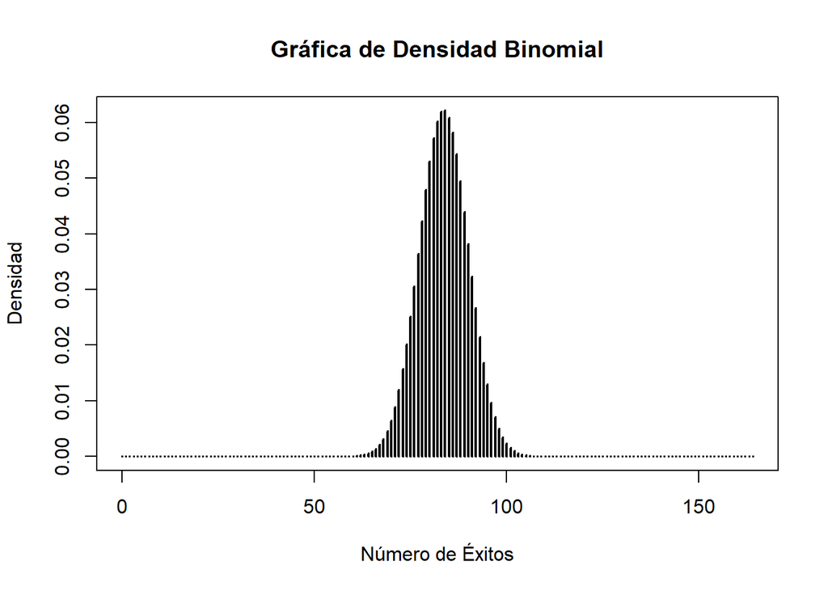

```r
# Parámetros de la distribución binomial
n <- 164  # Número de observaciones
p <- 0.51  # Probabilidad de éxito

# Valores del eje x (número de éxitos)
x <- 0:n

# Valores de densidad para la distribución binomial
densidad <- dbinom(x, n, p)

# Graficar la densidad
plot(x, densidad, type = "h", lwd = 2, main = "Gráfica de Densidad Binomial",
     xlab = "Número de Éxitos", ylab = "Densidad")
```

#### **- Quinto paso: Validar las propiedades**

**- Valor esperado y varianza**

$$= E(x) = n*p$$

$$σ2 = n*p(1-p)$$

```r
n <- 164  # Número de observaciones
p <- 0.51  # Probabilidad de éxito

# Valor esperado

E_x <- n * p

E_x
```

```
## [1] 83.64
```

```r
# Varianza

var <- (n*p)*(1-p)

var
```

```
## [1] 40.9836
```

#### **- sexto paso: Construir un ejemplo**

**Ejemplo**

```r
# Py + Px = 1


pbinom(83, 164, 0.49, lower.tail = FALSE, log.p = FALSE)
```

```
## [1] 0.3118232
```

```r
pbinom(80, 164, 0.51, lower.tail = TRUE, log.p = FALSE)
```

```
## [1] 0.3118232
```

**- Conclusión:**

Podemos ver que los dos resultados son iguales, entonces podemos decir que la distribución binomial esta bien ajustada en este caso ya que al verificar que dichas probabilidades son iguales estamos comprobando de que la P(a) es igual a su complemento.

### **2° VARIABLE**

#### **- Primer paso: Definir que distribución se usará**

**- Variable: Nivel_de_confianza - categórica ordinal**

**Distribución:** Geométrica

**Notación:**
$$x ~
Geom(p)$$

#### - Segundo paso: Definir la variable aleatoria__

- x: Cantidad de estudiantes encuestados hasta encontrar uno con perspectiva de confiabilidad (éxito).

#### **- Tercer paso: Identificar parámetros**

$$x ~ Geom(p)$$

**- Éxito:** Encontrar un estudiante que tenga una perspectiva de confiabilidad respecto a la veracidad de información que encuentra en linea

- p = 0.4 = 40% (Probabilidad de éxito)

```r
fr3 <- table(datos_filtrados1$Nivel_confianza)

fr3_A3 <- fr3["Confiable"]

Pe2 <- round(fr3_A3/N_total, 2)

Pe2
```

```
## Confiable
##       0.4
```

#### **- Cuarto paso: Construir la densidad**

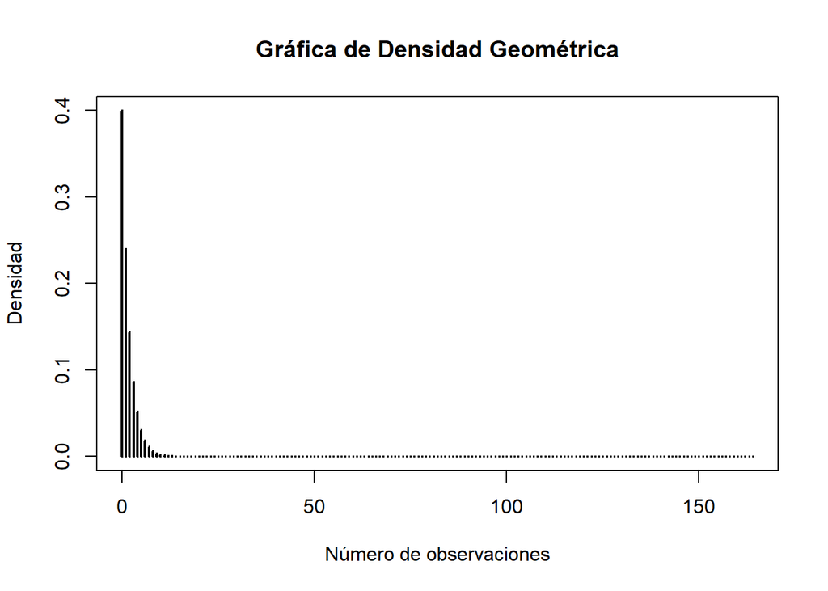

```r
# Parámetro de la distribución geométrica
n <- 164  # Número de observaciones
p <- 0.4  # Probabilidad de éxito

# Valores del eje x (número de ensayos)
x <- 0:n

# Valores de densidad para la distribución geométrica
densidad <- dgeom(x, p)

# Graficar la densidad
plot(x, densidad, type = "h", lwd = 2, main = "Gráfica de Densidad Geométrica",
     xlab = "Número de observaciones", ylab = "Densidad")
```

#### **- Quinto paso: Validar parámetros**

**- Valor esperado y varianza**

$$μ = E(x) = 1/p$$

$$σ2 = (1-p)/p2$$

```r
n <- 164  # Número de observaciones
p <- 0.4  # Probabilidad de éxito

# Valor esperado

E_x <- 1/p

E_x
```

```
## [1] 2.5
```

```r
# Varianza

var <- (1-p)/p^2

var
```

```
## [1] 3.75
```

#### **- Sexto paso: Construir ejemplo**

**- Ejemplo**

**- Éxito:** Encontrar un estudiante con percepción de confiabilidad

```r
dgeom(x=18, prob = 0.40)
```

```
## [1] 4.062398e-05
```

**- Conclusión:** Los números coinciden con la gráfica de la distribución geométrica, ya que mientras mayor sea el número de estudiantes a evaluar para recién conseguir uno que tenga una percepción de confiabilidad, menor sera el porcentaje de probabilidad porque es mucho más difícil encontrar casi ningun estudiante que tenga una percepción de confiabilidad en un rango amplio dentro del rango que se determina.

### **VARIABLES CONTINUAS**

- Datos importantes:

```r
# Cantidad total de estudiantes encuestados
N_total
```

```
## [1] 163
```

```r
# Opciones únicas de la variable

varia1 <- unique(datos_filtrados1$Tiempo_de_demora)

varia1
```

```
##  [1]   5  10   8   6   9   3   4  15 120  20  30   2   7  65  12   1  16  80  40
```

```r
# Opciones únicas de la variable

varia2 <- unique(datos_filtrados1$Tmax_estudio_digital)

varia2
```

```
##  [1] 25 20 12 24 30 15 22 40 19 17 50 18 23 21 70 35 45  8 42  5 16 55  0 10 11
## [26] 28 14 62  6 72  2  3  4 48
```

#### **- Primer paso: Identificar gráficamente la variable Tiempo_de_demora**

```r
library(EnvStats)
```

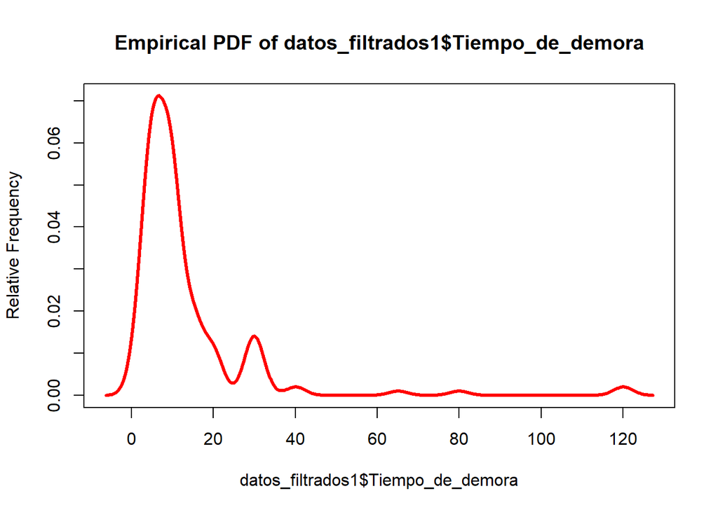

```r
epdfPlot(datos_filtrados1$Tiempo_de_demora, epdf.col = "red")
```

#### **- Segundo paso: Validación**

**- Media ≅ Mediana**

$$(\overline {X}) ≅ Me$$

```r
# Vector con el primer y tercer cuartil
cuartiles <- c(0:120)
# Número de datos
n <- length(cuartiles)
# Suma de los datos
suma <- sum(cuartiles)
# Media aritmética
media <- suma / n
media
```

```
## [1] 60
```

```r
Tiempo_de_demoraSort <- sort(datos_filtrados1$Tiempo_de_demora)
mediana <- median(Tiempo_de_demoraSort)
mediana
```

```
## [1] 10
```

#### **- Verificación de la Media y Mediana**

**- Media y mediana diferentes**

**- Reducción de la gráfica**

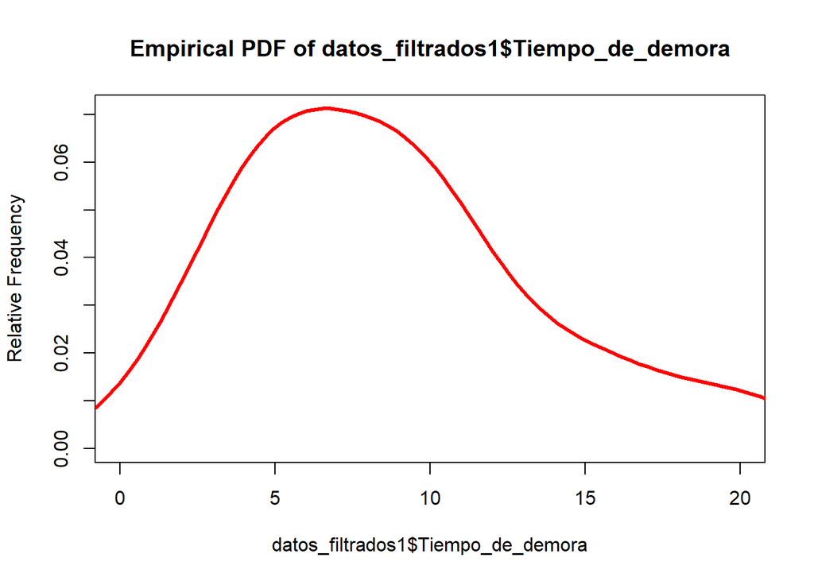

```r
library(EnvStats)
epdfPlot(datos_filtrados1$Tiempo_de_demora, epdf.col = "red",xlim=c(0,20))
```

**- Nueva validación de Media ≅ Mediana**

$$(\overline {X}) ≅ Me$$

```r
# Vector con el primer y tercer cuartil
Cuartiles <- c(0,20)
# Número de datos
N <- length(Cuartiles)
# Suma de los datos
Suma <- sum(Cuartiles)
# Media aritmética
Meedia <- Suma / N
Meedia
```

```
## [1] 10
```

```r
# 10
```

```r
Tiempo_de_demoraSort <- sort(datos_filtrados1$Tiempo_de_demora)
mediana <- median(Tiempo_de_demoraSort)
mediana
```

```
## [1] 10
```

**- Desviación estándar**

$$Sd$$
**- Para hallar la desviación estándar de una variable aleatoria Tiempo_de_demora, usamos la función *sd***

```r
sd(datos_filtrados1$Tiempo_de_demora)
```

```
## [1] 15.98516
```

**- Varianza**

$$V({X}) ≅ Sd^2(Tiempo de
demora)$$

**- Para hallar la varianza de una variable aleatoria Tiempo_de_demora, usamos la función *var***

```r
var(datos_filtrados1$Tiempo_de_demora)
```

```
## [1] 255.5254
```

- La varianza es 255.5254

**- Esperanza =**

$$E({X}) ≅ mean(Tiempo de
demora)$$

**- Para hallar la esperanza de una variable aleatoria Tiempo_de_demora, usamos la función *mean*.**

```r
mean(datos_filtrados1$Tiempo_de_demora)
```

```
## [1] 13.07362
```

**- Otra manera de validar la esperanza**

```r
esperanza <- sum(datos_filtrados1$Tiempo_de_demora) / length(datos_filtrados1$Tiempo_de_demora)
esperanza
```

```
## [1] 13.07362
```

```r
summary(datos_filtrados1$Tiempo_de_demora)
```

```
##    Min. 1st Qu.  Median    Mean 3rd Qu.    Max.
##    1.00    5.00   10.00   13.07   15.00  120.00
```